# CKME 136 - Breast Cancer Diagnosis

Ping Li

July 24, 2018

# Preparation and Data Import

## Loading packages

```r
library(plyr)
library(tidyverse)
library(caret)
library(caretEnsemble)
library(funModeling)
```

```r
library(corrplot)
library(factoextra)
library(C50)
library(naivebayes)
library(fastAdaboost)
set.seed(44)
```

## Uploading dataset

```r
wdbc <- read_csv("https://raw.githubusercontent.com/ping-li/CKME-136/master/data.csv")
```

Taking a look at the data:

```r
head(wdbc)
```

```
## # A tibble: 6 x 11
##       id clump_thickness size_uniformity shape_uniformity marginal_adhesi~
##    <int>           <int>           <int>            <int>            <int>
## 1 1.00e6               5               1                1                1
## 2 1.00e6               5               4                4                5
## 3 1.02e6               3               1                1                1
## 4 1.02e6               6               8                8                1
## 5 1.02e6               4               1                1                3
## 6 1.02e6               8              10               10                8
## # ... with 6 more variables: epithelial_size <int>, bare_nucleoli <chr>,
## #   bland_chromatin <int>, normal_nucleoli <int>, mitoses <int>,
## #   class <int>
```

# Data Cleaning and Exploratory Data Analysis

## Checking for missing values, attribute types, and formatting

Taking a look at the structure of each variable:

```r
str(wdbc)
```

```
## Classes 'tbl_df', 'tbl' and 'data.frame':    699 obs. of  11 variables:
##  $ id               : int  1000025 1002945 1015425 1016277 1017023 1017122 1018099 1018561 1033078 1033078 ...
##  $ clump_thickness  : int  5 5 3 6 4 8 1 2 2 4 ...
##  $ size_uniformity  : int  1 4 1 8 1 10 1 1 1 2 ...
##  $ shape_uniformity : int  1 4 1 8 1 10 1 2 1 1 ...
##  $ marginal_adhesion: int  1 5 1 1 3 8 1 1 1 1 ...
##  $ epithelial_size  : int  2 7 2 3 2 7 2 2 2 2 ...
##  $ bare_nucleoli    : chr  "1" "10" "2" "4" ...
##  $ bland_chromatin  : int  3 3 3 3 3 9 3 3 1 2 ...
##  $ normal_nucleoli  : int  1 2 1 7 1 7 1 1 1 1 ...
##  $ mitoses          : int  1 1 1 1 1 1 1 1 5 1 ...
##  $ class            : int  2 2 2 2 2 4 2 2 2 2 ...
##  - attr(*, "spec")=List of 2
##   ..$ cols   :List of 11
##   .. ..$ id               : list()
##   .. .. ..- attr(*, "class")= chr  "collector_integer" "collector"
##   .. ..$ clump_thickness  : list()
##   .. .. ..- attr(*, "class")= chr  "collector_integer" "collector"
##   .. ..$ size_uniformity  : list()
##   .. .. ..- attr(*, "class")= chr  "collector_integer" "collector"
##   .. ..$ shape_uniformity : list()
##   .. .. ..- attr(*, "class")= chr  "collector_integer" "collector"
##   .. ..$ marginal_adhesion: list()
##   .. .. ..- attr(*, "class")= chr  "collector_integer" "collector"
##   .. ..$ epithelial_size  : list()
##   .. .. ..- attr(*, "class")= chr  "collector_integer" "collector"
##   .. ..$ bare_nucleoli    : list()
##   .. .. ..- attr(*, "class")= chr  "collector_character" "collector"
##   .. ..$ bland_chromatin  : list()
##   .. .. ..- attr(*, "class")= chr  "collector_integer" "collector"
##   .. ..$ normal_nucleoli  : list()
##   .. .. ..- attr(*, "class")= chr  "collector_integer" "collector"
##   .. ..$ mitoses          : list()
##   .. .. ..- attr(*, "class")= chr  "collector_integer" "collector"
##   .. ..$ class            : list()
##   .. .. ..- attr(*, "class")= chr  "collector_integer" "collector"
##   ..$ default: list()
##   .. ..- attr(*, "class")= chr  "collector_guess" "collector"
##   ..- attr(*, "class")= chr "col_spec"
```

Upon inspection, it looks like every attribute is listed as an integer except for the ‘bare_nucleoli’ attribute. It must contain some non-integer values, so we will convert to integer and check for NA values. We will also change the name of the class attribute to ‘diagnosis’ and convert into a factor.

```r
wdbc$bare_nucleoli <- as.integer(wdbc$bare_nucleoli)
sapply(wdbc, function(x) sum(is.na(x))) %>% data.frame #Check for NA values
```

```
##                    .
## id                 0
## clump_thickness    0
## size_uniformity    0
## shape_uniformity   0
## marginal_adhesion  0
## epithelial_size    0
## bare_nucleoli     16
## bland_chromatin    0
## normal_nucleoli    0
## mitoses            0
## class              0
```

```r
wdbc <- na.omit(wdbc) #Removing records with NA
names(wdbc) <- c(names(wdbc[1:10]),"diagnosis")
wdbc$diagnosis <- as.factor(wdbc$diagnosis)
wdbc$diagnosis <- mapvalues(wdbc$diagnosis, c(2,4), c("Benign","Malignant"))
```

We can also remove the ‘id’ attribute as it simply serves as a unique identifier and does not contribute any predictive value. We can also separate into attributes and class.

```r
wdbc <- wdbc[,-1]
wdbc_a <- wdbc[,1:9] # WDBC attributes
wdbc_c <- wdbc$diagnosis # WDBC class attribute
```

## Distribution plots of each attribute

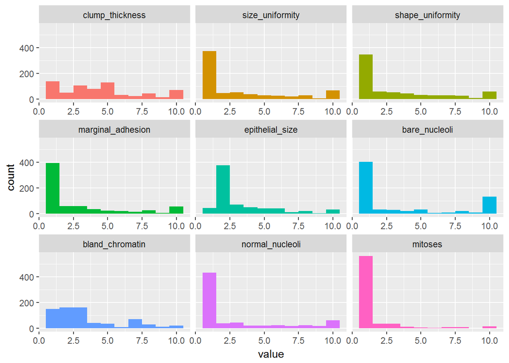

```r
plot_num(wdbc_a)
```

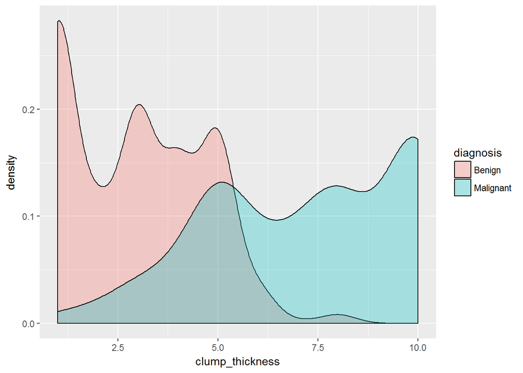

```r
ggplot(wdbc) + geom_density(aes(x=clump_thickness, fill = diagnosis), alpha=0.3)
```

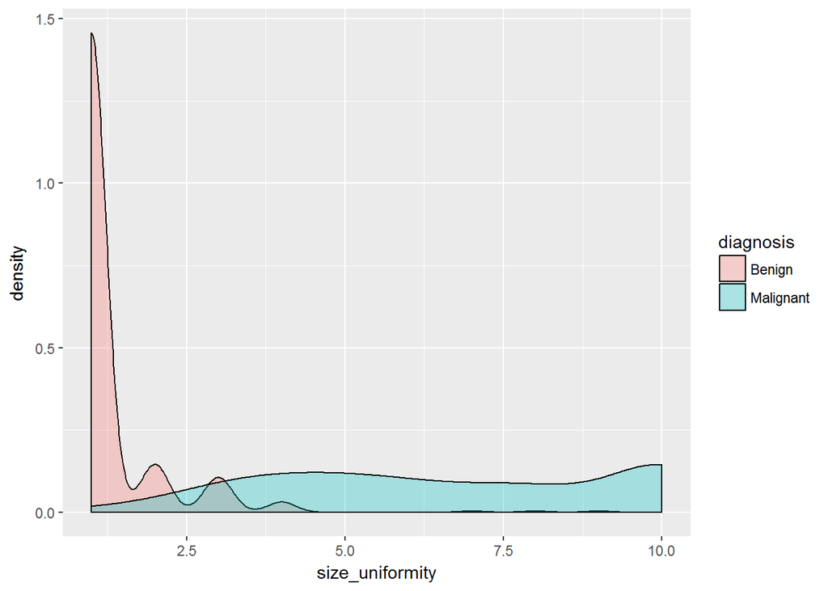

```r
ggplot(wdbc) + geom_density(aes(x=size_uniformity, fill = diagnosis), alpha=0.3)
```

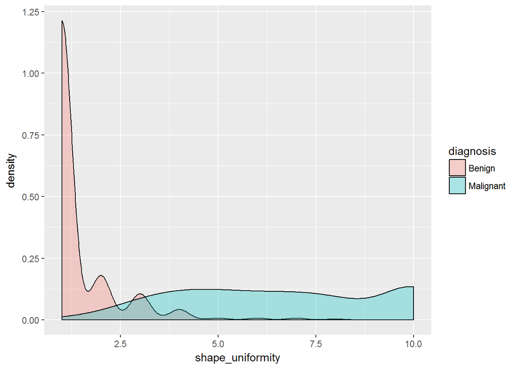

```r
ggplot(wdbc) + geom_density(aes(x=shape_uniformity, fill = diagnosis), alpha=0.3)
```

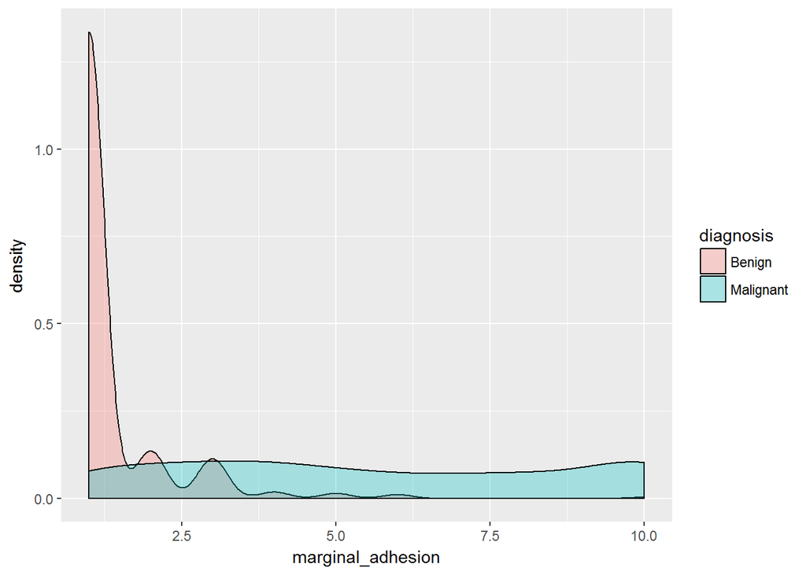

```r
ggplot(wdbc) + geom_density(aes(x=marginal_adhesion, fill = diagnosis), alpha=0.3)
```

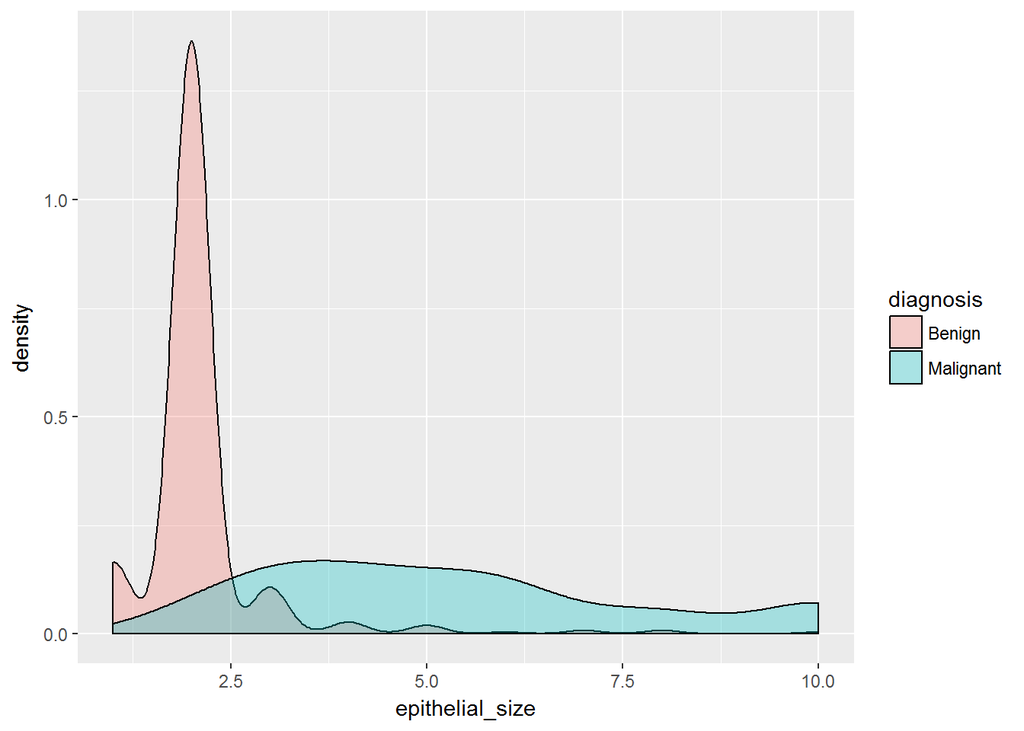

```r
ggplot(wdbc) + geom_density(aes(x=epithelial_size, fill = diagnosis), alpha=0.3)
```

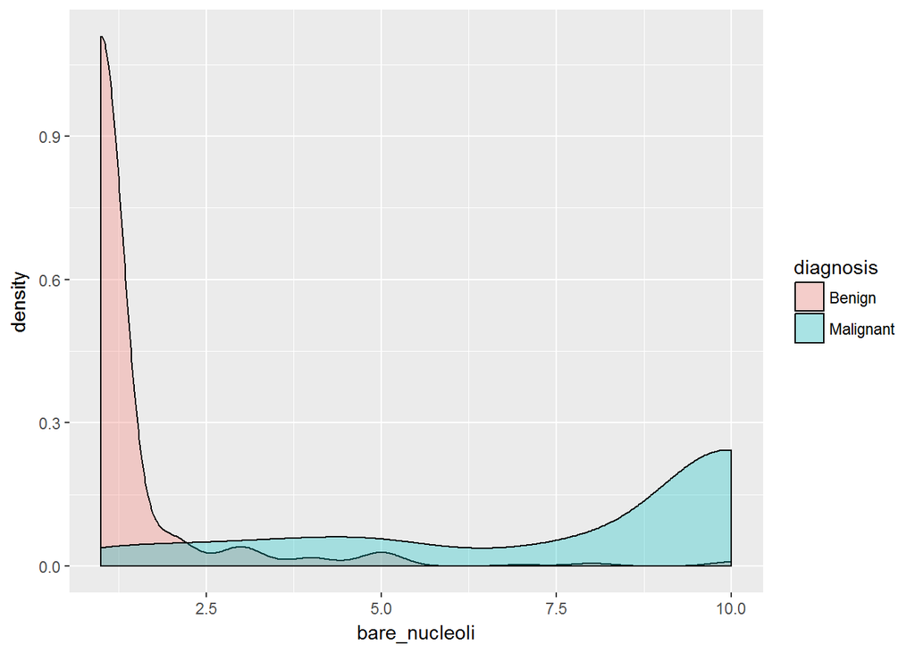

```r
ggplot(wdbc) + geom_density(aes(x=bare_nucleoli, fill = diagnosis), alpha=0.3)
```

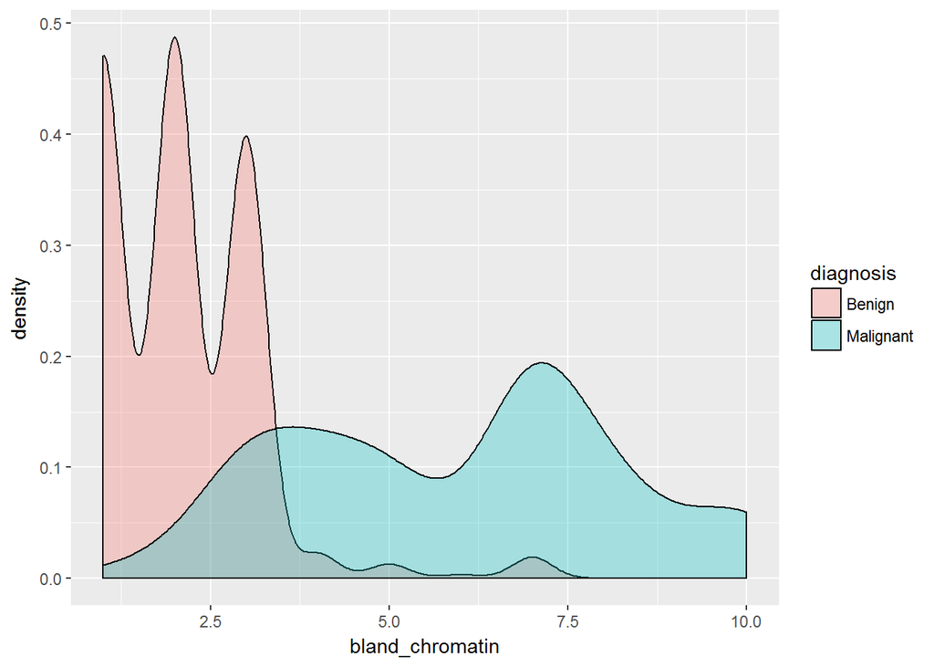

```r
ggplot(wdbc) + geom_density(aes(x=bland_chromatin, fill = diagnosis), alpha=0.3)
```

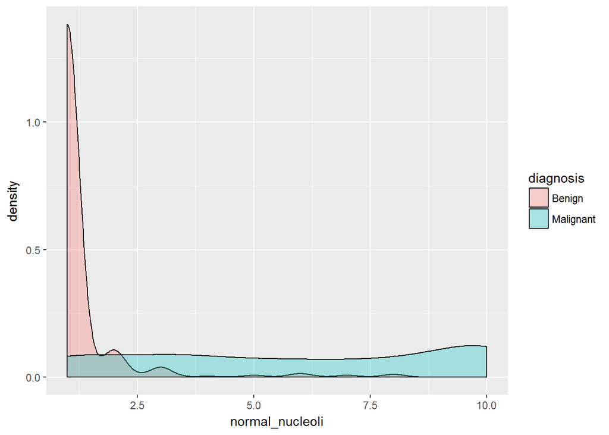

```r
ggplot(wdbc) + geom_density(aes(x=normal_nucleoli, fill = diagnosis), alpha=0.3)
```

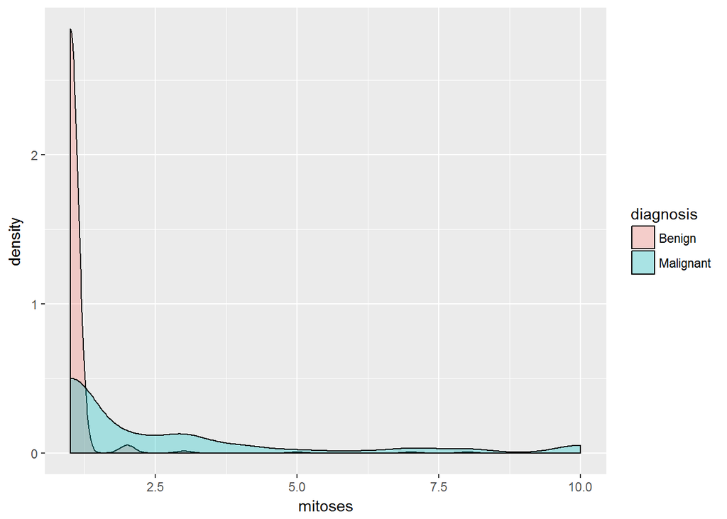

```r
ggplot(wdbc) + geom_density(aes(x=mitoses, fill = diagnosis), alpha=0.3)
```

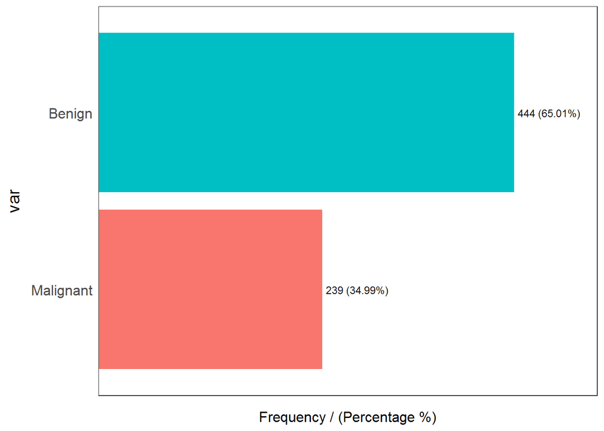

```
##         var frequency percentage cumulative_perc
## 1    Benign       444      65.01           65.01
## 2 Malignant       239      34.99          100.00
```

```r
freq(wdbc_c) # 65% Benign and 35% Malignant
```

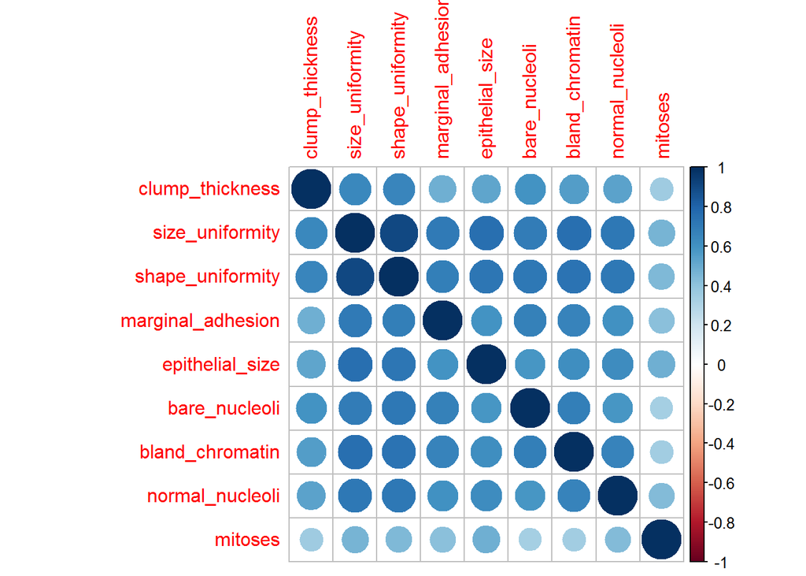

```r
wdbc_a %>% cor %>% corrplot
```

It appears that many of our attributes are strongly positively correlated.

# Data pre-processing

## PCA

Seeing has how a lot of the attributes are strongly correlated, we will use PCA to convert attributes into a set of uncorrelated components.

```r
pca_wdbc <- princomp(wdbc_a) # PCA on attributes
pc_wdbc <- pca_wdbc$scores # PCA scores
full_wdbc <- data.frame(pc_wdbc,wdbc_c) # Combining PC with class attribute
```

Taking a look at the resulting principal components:

```r
summary(pca_wdbc)
```

```
## Importance of components:
##                           Comp.1     Comp.2     Comp.3     Comp.4
## Standard deviation     6.9982536 2.25903450 2.07250492 1.77498764
## Proportion of Variance 0.6905076 0.07195066 0.06055921 0.04442012
## Cumulative Proportion  0.6905076 0.76245823 0.82301744 0.86743756
##                            Comp.5     Comp.6     Comp.7     Comp.8
## Standard deviation     1.66328370 1.56289816 1.33943265 1.26229092
## Proportion of Variance 0.03900513 0.03443899 0.02529478 0.02246508
## Cumulative Proportion  0.90644270 0.94088169 0.96617646 0.98864155
##                            Comp.9
## Standard deviation     0.89756328
## Proportion of Variance 0.01135845
## Cumulative Proportion  1.00000000
```

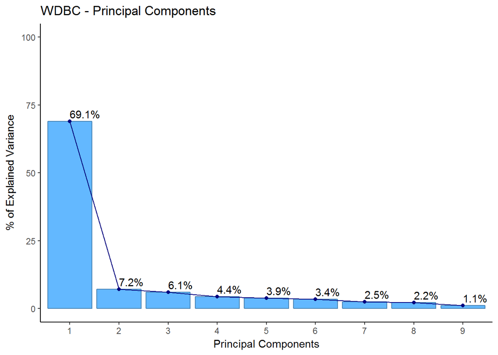

```r
fviz_eig(pca_wdbc, addlabels = TRUE, ylim = c(0,100), barfill = "steelblue1", line="navy") +
  theme_classic() +
  labs(x = "Principal Components", y = "% of Explained Variance", title = "WDBC - Principal Components")
```

We see that 69% of the variance is explained by the first principal component.

# Individual machine learning models

## Model Creation

Models will be created using 5-fold cross-validation, given the relatively small sample size of the dataset. Setting parameters below:

```r
# Setting up 5-fold cross-validation
ctrl <- trainControl(method = "cv",
                     number = 5)

# Function for plotting confusion matrices
cm_plot <- function(ml, title) {
  confusionMatrix(ml)$table %>%
    round(1) %>%
    fourfoldplot(
      color = c("#CC6666", "#99CC99"),
      main=title,
      conf.level=0,
      margin=1
    )
}
```

### Decision Tree

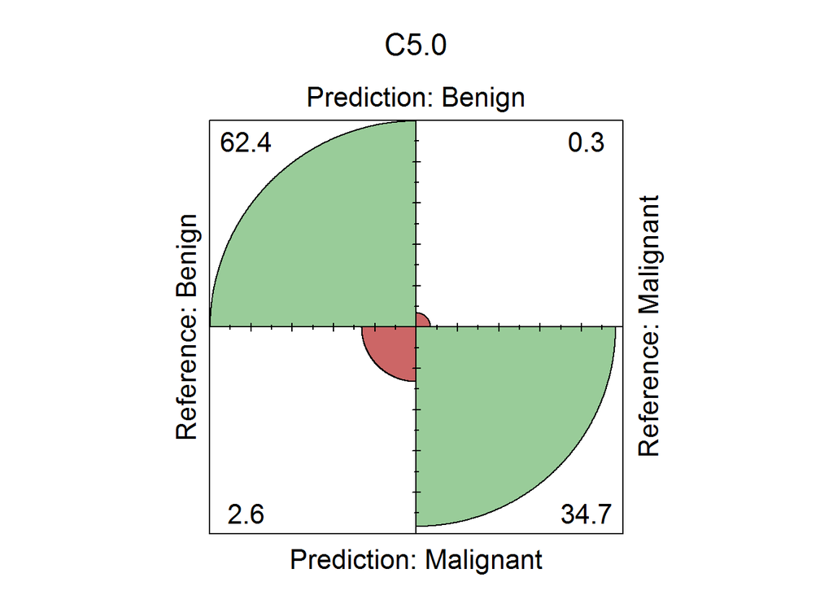

```r
# Using C5.0 algorithm
c50.ml <- train(wdbc_c~., full_wdbc, method = "C5.0", trControl = ctrl)
c50.cm <- confusionMatrix(c50.ml)
cm_plot(c50.ml, "C5.0")
```

```r
c50.metrics <- data.frame (
  "Model" = "C5.0",
  "Accuracy" = (c50.cm$table[1,1] + c50.cm$table[2,2])/100,
  "Recall" = c50.cm$table[2,2] / (c50.cm$table[2,2] + c50.cm$table[1,2]), #True positive rate
  "Precision" = c50.cm$table[2,2] / (c50.cm$table[2,1] + c50.cm$table[2,2]),
  "FNR" = (c50.cm$table[1,2] / (c50.cm$table[2,2] + c50.cm$table[1,2])), #False negative rate
  "Fscore" = (2 * c50.cm$table[2,2]) / (2 * c50.cm$table[2,2] + c50.cm$table[1,2] + c50.cm$table[2,1])
)
c50.metrics
```

```
##   Model  Accuracy    Recall Precision         FNR    Fscore
## 1  C5.0 0.9707174 0.9916318 0.9294118 0.008368201 0.9595142
```

### k-Nearest Neighbours

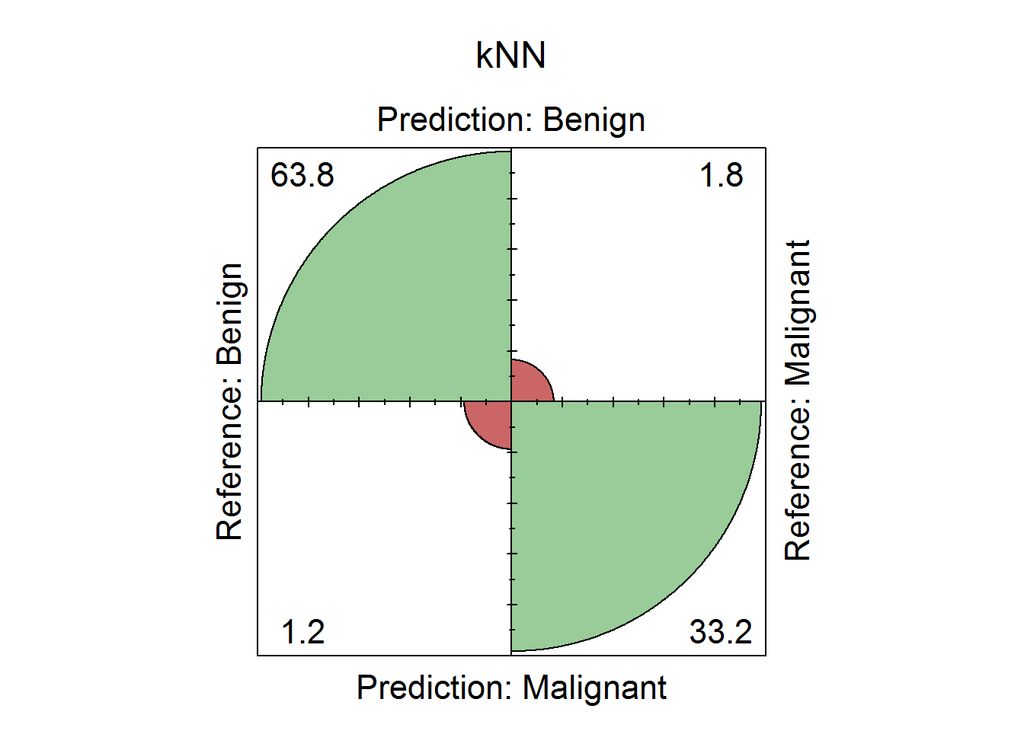

```r
knn.ml <- train(wdbc_c~., full_wdbc, method = "knn", trControl =ctrl)
knn.cm <- confusionMatrix(knn.ml)
cm_plot(knn.ml, "kNN")
```

```r
knn.metrics <- data.frame (
  "Model" = "k-NN",
  "Accuracy" = (knn.cm$table[1,1] + knn.cm$table[2,2])/100,
  "Recall" = knn.cm$table[2,2] / (knn.cm$table[2,2] + knn.cm$table[1,2]),
  "Precision" = knn.cm$table[2,2] / (knn.cm$table[2,1] + knn.cm$table[2,2]),
  "FNR" = (knn.cm$table[1,2] / (knn.cm$table[2,2] + knn.cm$table[1,2])),
  "Fscore" = (2 * knn.cm$table[2,2]) / (2 * knn.cm$table[2,2] + knn.cm$table[1,2] + knn.cm$table[2,1])
)
knn.metrics
```

```
##   Model  Accuracy    Recall Precision        FNR    Fscore
## 1  k-NN 0.9707174 0.9497908 0.9659574 0.05020921 0.9578059
```

### Naive Bayes

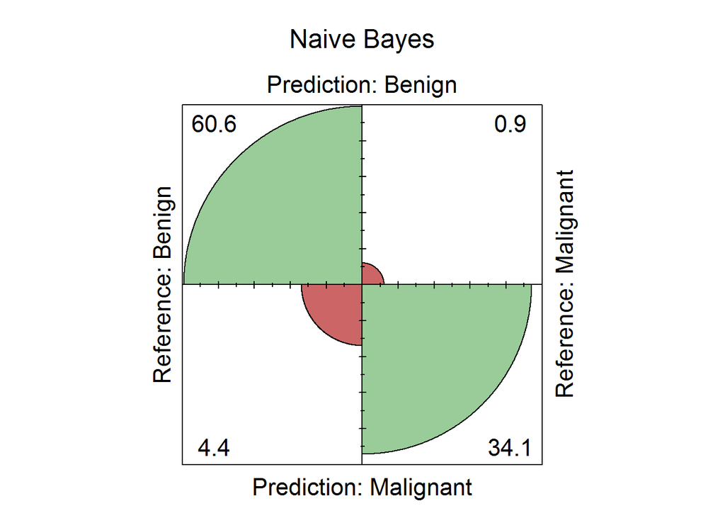

```r
nb.ml <- train(wdbc_c~., full_wdbc, method = "naive_bayes", trControl =ctrl)
nb.cm <- confusionMatrix(nb.ml)
cm_plot(nb.ml, "Naive Bayes")
```

```r
nb.metrics <- data.frame (
  "Model" = "Naive Bayes",
  "Accuracy" = (nb.cm$table[1,1] + nb.cm$table[2,2])/100,
  "Recall" = nb.cm$table[2,2] / (nb.cm$table[2,2] + nb.cm$table[1,2]),
  "Precision" = nb.cm$table[2,2] / (nb.cm$table[2,1] + nb.cm$table[2,2]),
  "FNR" = (nb.cm$table[1,2] / (nb.cm$table[2,2] + nb.cm$table[1,2])),
  "Fscore" = (2 * nb.cm$table[2,2]) / (2 * nb.cm$table[2,2] + nb.cm$table[1,2] + nb.cm$table[2,1])
)
nb.metrics
```

```
##         Model  Accuracy    Recall Precision       FNR    Fscore
## 1 Naive Bayes 0.9472914 0.9748954 0.8859316 0.0251046 0.9282869
```

### Logistic Regression

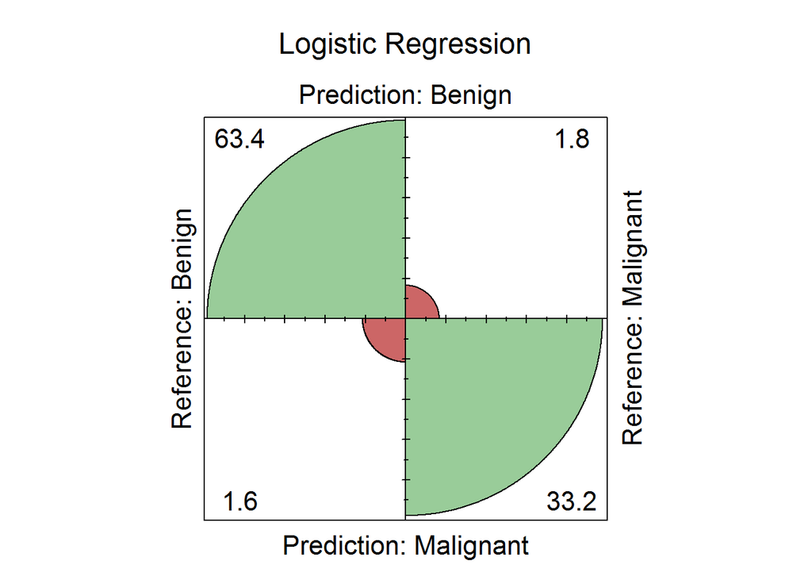

```r
logit.ml <- train(wdbc_c~., full_wdbc, method = "glm", family = "binomial", trControl =ctrl)
logit.cm <- confusionMatrix(logit.ml)
cm_plot(logit.ml, "Logistic Regression")
```

```r
logit.metrics <- data.frame (
  "Model" = "Logistic Regression",
  "Accuracy" = (logit.cm$table[1,1] + logit.cm$table[2,2])/100,
  "Recall" = logit.cm$table[2,2] / (logit.cm$table[2,2] + logit.cm$table[1,2]),
  "Precision" = logit.cm$table[2,2] / (logit.cm$table[2,1] + logit.cm$table[2,2]),
  "FNR" = (logit.cm$table[1,2] / (logit.cm$table[2,2] + logit.cm$table[1,2])),
  "Fscore" = (2 * logit.cm$table[2,2]) / (2 * logit.cm$table[2,2] + logit.cm$table[1,2] + logit.cm$table[2,1])
)
logit.metrics
```

```
##                 Model Accuracy    Recall Precision        FNR   Fscore
## 1 Logistic Regression 0.966325 0.9497908 0.9537815 0.05020921 0.951782
```

### Support Vector Machine (SVM)

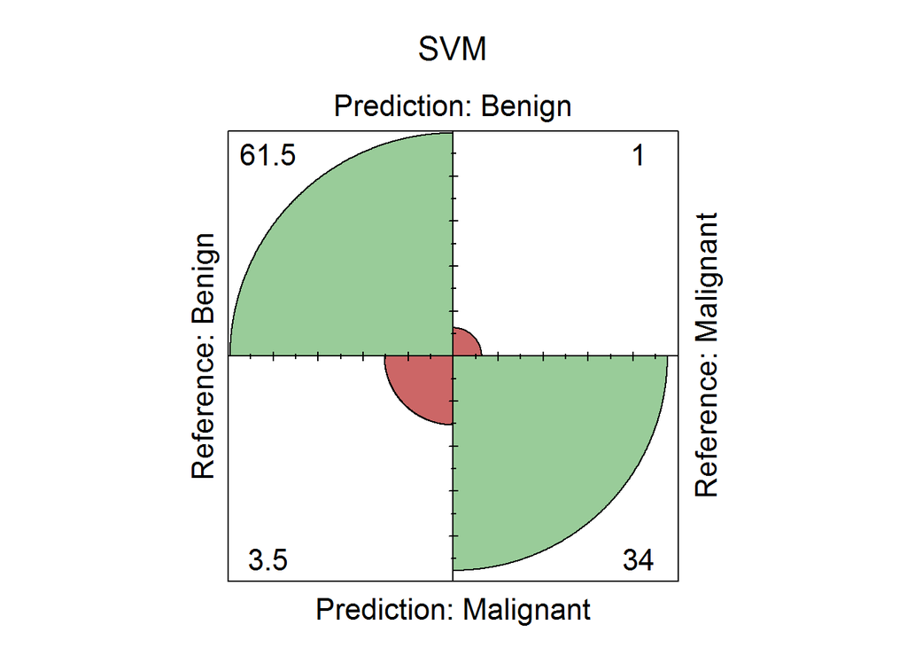

```r
svm.ml <- train(wdbc_c~., full_wdbc, method = "svmRadial", trControl =ctrl)
svm.cm <- confusionMatrix(svm.ml)
cm_plot(svm.ml, "SVM")
```

```r
svm.metrics <- data.frame (
  "Model" = "SVM",
  "Accuracy" = (svm.cm$table[1,1] + svm.cm$table[2,2])/100,
  "Recall" = svm.cm$table[2,2] / (svm.cm$table[2,2] + svm.cm$table[1,2]),
  "Precision" = svm.cm$table[2,2] / (svm.cm$table[2,1] + svm.cm$table[2,2]),
  "FNR" = (svm.cm$table[1,2] / (svm.cm$table[2,2] + svm.cm$table[1,2])),
  "Fscore" = (2 * svm.cm$table[2,2]) / (2 * svm.cm$table[2,2] + svm.cm$table[1,2] + svm.cm$table[2,1])
)
svm.metrics
```

```
##   Model Accuracy    Recall Precision       FNR    Fscore
## 1   SVM 0.954612 0.9707113   0.90625 0.0292887 0.9373737
```

## Model Performance

```r
metrics1 <- rbind(c50.metrics, knn.metrics, nb.metrics, logit.metrics, svm.metrics)
metrics1 # Taking a look at everything together
```

```
##                 Model  Accuracy    Recall Precision         FNR    Fscore
## 1                C5.0 0.9707174 0.9916318 0.9294118 0.008368201 0.9595142
## 2                k-NN 0.9707174 0.9497908 0.9659574 0.050209205 0.9578059
## 3         Naive Bayes 0.9472914 0.9748954 0.8859316 0.025104603 0.9282869
## 4 Logistic Regression 0.9663250 0.9497908 0.9537815 0.050209205 0.9517820
## 5                 SVM 0.9546120 0.9707113 0.9062500 0.029288703 0.9373737
```

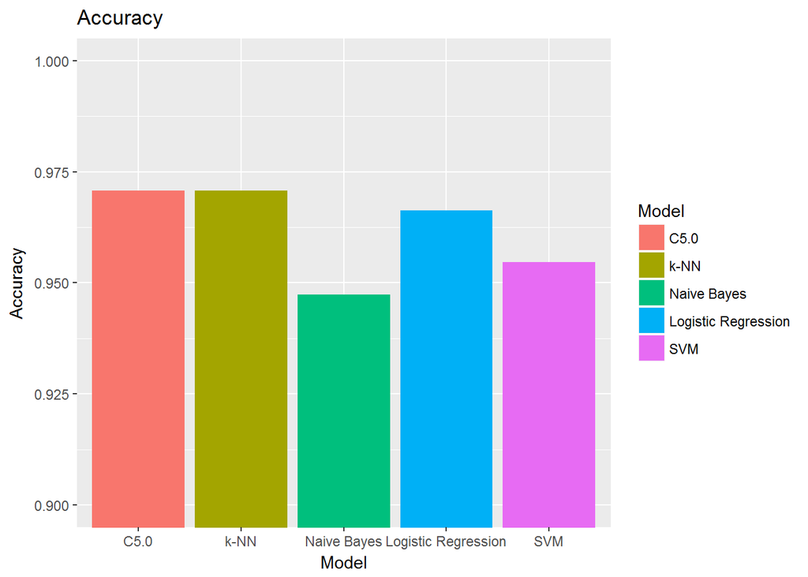

```r
ggplot(metrics1, aes(Model, Accuracy)) + geom_bar(stat="identity", aes(fill=Model)) + coord_cartesian(ylim=c(0.9,1)) + ggtitle("Accuracy")
```

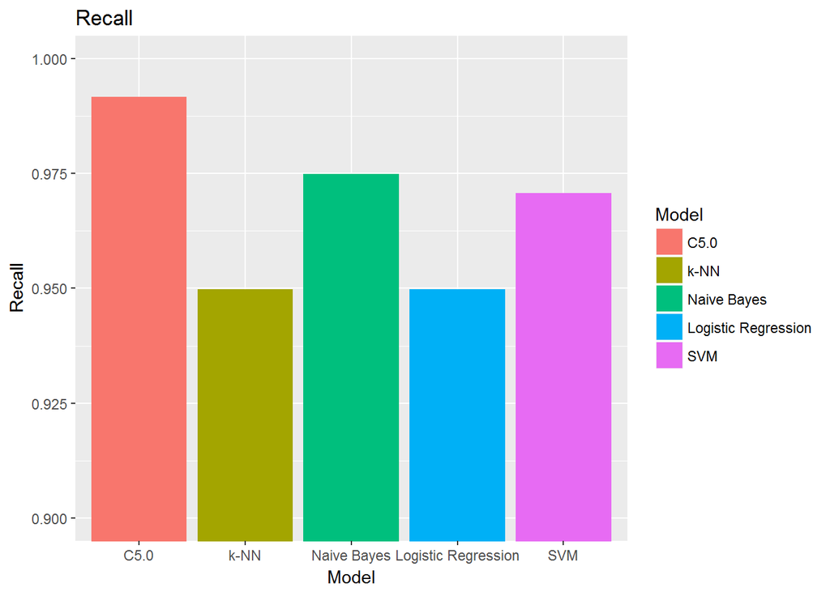

```r
ggplot(metrics1, aes(Model, Recall)) + geom_bar(stat="identity", aes(fill=Model)) + coord_cartesian(ylim=c(0.9,1)) + ggtitle("Recall")
```

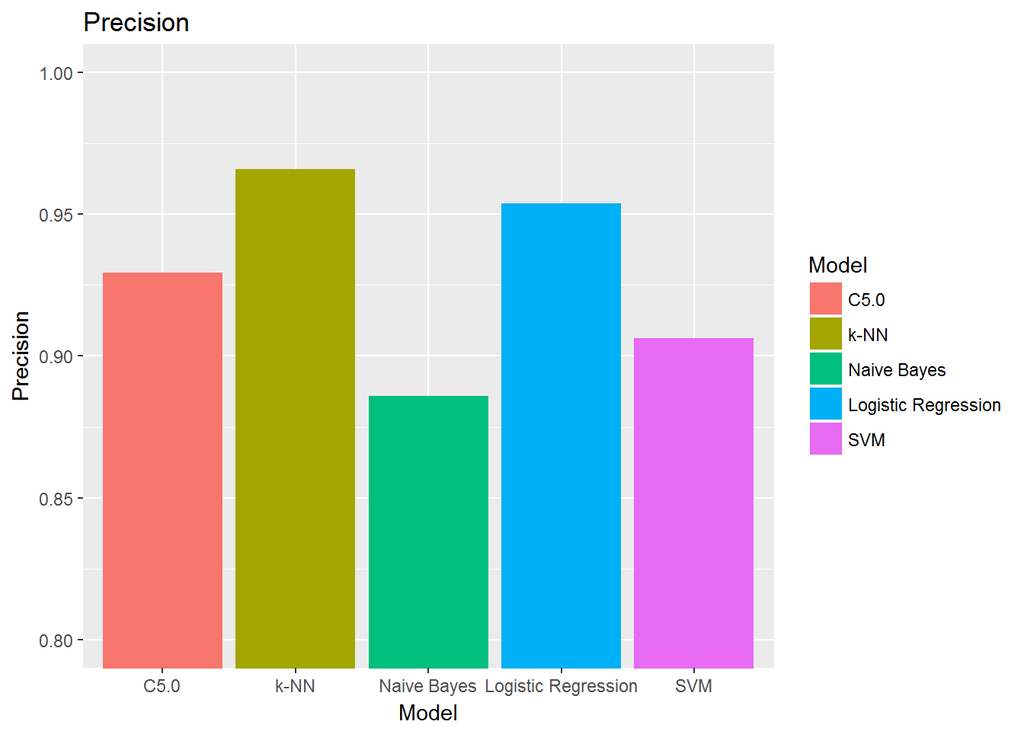

```r
ggplot(metrics1, aes(Model, Precision)) + geom_bar(stat="identity", aes(fill=Model)) + coord_cartesian(ylim=c(0.8,1)) + ggtitle("Precision")
```

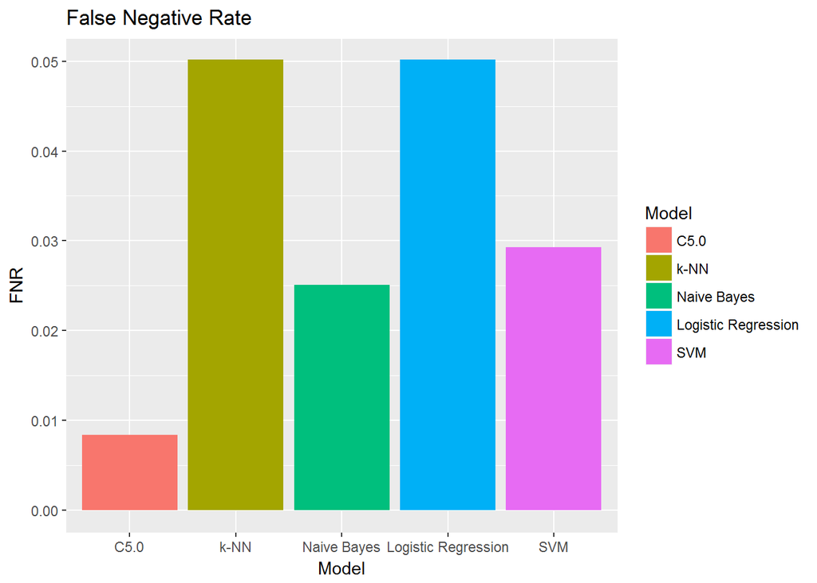

```r
ggplot(metrics1, aes(Model, FNR)) + geom_bar(stat="identity", aes(fill=Model)) + coord_cartesian(ylim=c(0,0.05)) + ggtitle("False Negative Rate")
```

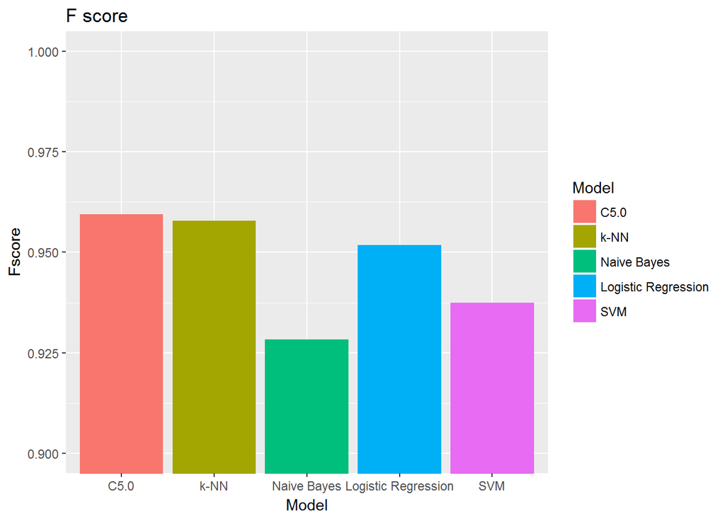

```r
ggplot(metrics1, aes(Model, Fscore)) + geom_bar(stat="identity", aes(fill=Model)) + coord_cartesian(ylim=c(0.9,1)) + ggtitle("F score")
```

# Ensemble learning models

## Model Creation

### Bagging - Random Forest

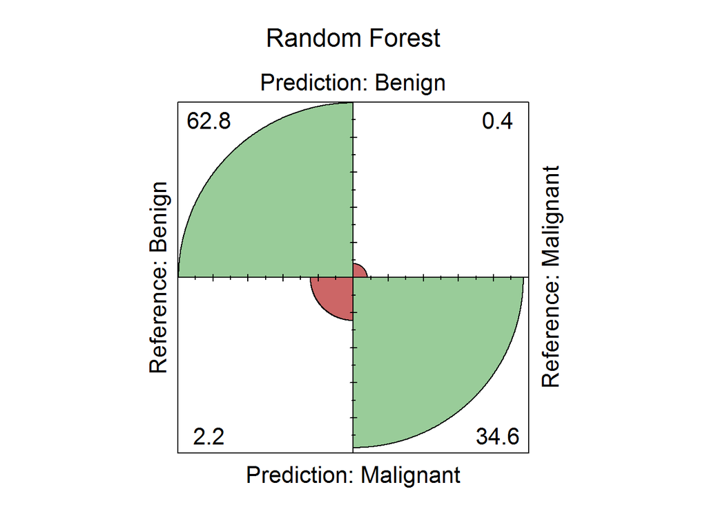

```r
rf.ml <- train(wdbc_c~., full_wdbc, method = "rf", trControl =ctrl)
rf.cm <- confusionMatrix(rf.ml)
cm_plot(rf.ml, "Random Forest")
```

```r
rf.metrics <- data.frame (
  "Model" = "Random Forest",
  "Accuracy" = (rf.cm$table[1,1] + rf.cm$table[2,2])/100,
  "Recall" = rf.cm$table[2,2] / (rf.cm$table[2,2] + rf.cm$table[1,2]),
  "Precision" = rf.cm$table[2,2] / (rf.cm$table[2,1] + rf.cm$table[2,2]),
  "FNR" = (rf.cm$table[1,2] / (rf.cm$table[2,2] + rf.cm$table[1,2])),
  "Fscore" = (2 * rf.cm$table[2,2]) / (2 * rf.cm$table[2,2] + rf.cm$table[1,2] + rf.cm$table[2,1])
)
rf.metrics
```

```
##           Model  Accuracy    Recall Precision       FNR    Fscore
## 1 Random Forest 0.9736457 0.9874477  0.940239 0.0125523 0.9632653
```

### Boosting - AdaBoost

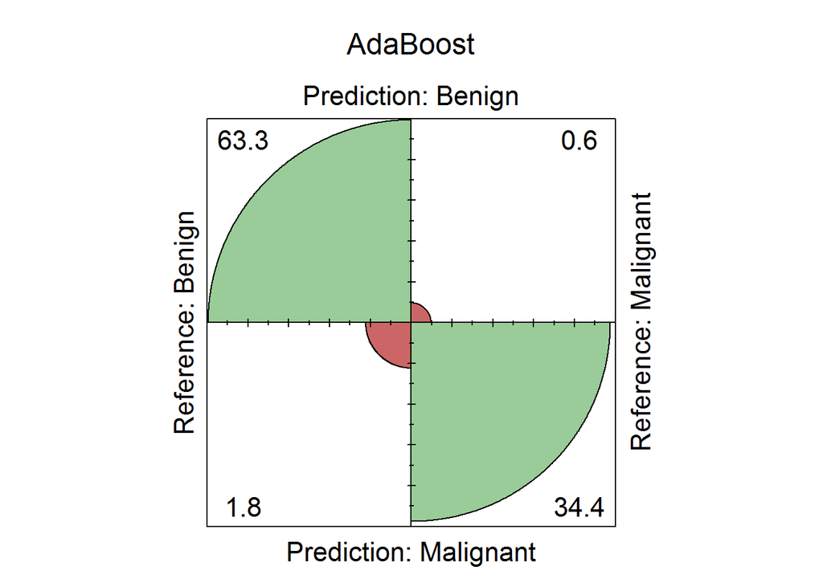

```r
ada.ml <- train(wdbc_c~., full_wdbc, method = "adaboost", trControl =ctrl)
ada.cm <- confusionMatrix(ada.ml)
cm_plot(ada.ml, "AdaBoost")
```

```r
ada.metrics <- data.frame (
  "Model" = "AdaBoost",
  "Accuracy" = (ada.cm$table[1,1] + ada.cm$table[2,2])/100,
  "Recall" = ada.cm$table[2,2] / (ada.cm$table[2,2] + ada.cm$table[1,2]),
  "Precision" = ada.cm$table[2,2] / (ada.cm$table[2,1] + ada.cm$table[2,2]),
  "FNR" = (ada.cm$table[1,2] / (ada.cm$table[2,2] + ada.cm$table[1,2])),
  "Fscore" = (2 * ada.cm$table[2,2]) / (2 * ada.cm$table[2,2] + ada.cm$table[1,2] + ada.cm$table[2,1])
)
ada.metrics
```

```
##      Model  Accuracy    Recall Precision       FNR    Fscore
## 1 AdaBoost 0.9765739 0.9832636  0.951417 0.0167364 0.9670782
```

### Boosting - Gradient Boosting Machine

```r
gbm.ml <- train(wdbc_c~., full_wdbc, method = "gbm", trControl =ctrl)
```

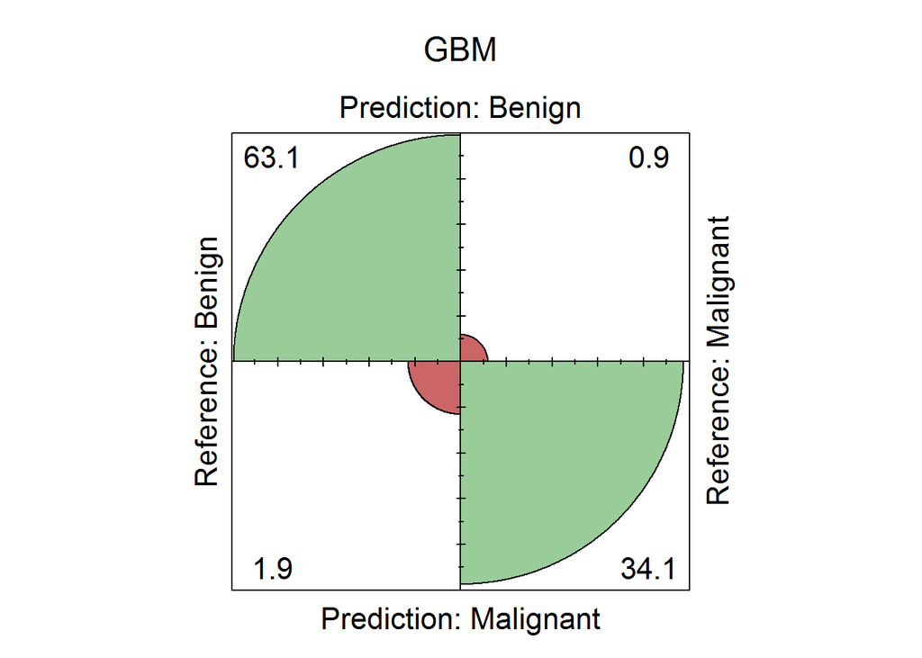

```r
gbm.cm <- confusionMatrix(gbm.ml)
cm_plot(gbm.ml, "GBM")
```

```r
gbm.metrics <- data.frame (
  "Model" = "GBM",
  "Accuracy" = (gbm.cm$table[1,1] + gbm.cm$table[2,2])/100,
  "Recall" = gbm.cm$table[2,2] / (gbm.cm$table[2,2] + gbm.cm$table[1,2]),
  "Precision" = gbm.cm$table[2,2] / (gbm.cm$table[2,1] + gbm.cm$table[2,2]),
  "FNR" = (gbm.cm$table[1,2] / (gbm.cm$table[2,2] + gbm.cm$table[1,2])),
  "Fscore" = (2 * gbm.cm$table[2,2]) / (2 * gbm.cm$table[2,2] + gbm.cm$table[1,2] + gbm.cm$table[2,1])
)
gbm.metrics
```

```
##   Model  Accuracy    Recall Precision       FNR    Fscore
## 1   GBM 0.9721816 0.9748954 0.9471545 0.0251046 0.9608247
```

### Stacking - Putting it all together

```r
ml_set <- c("C5.0","knn","naive_bayes","glm","svmRadial")
ctrl2 <- trainControl(method = "cv", number = 5, savePredictions = "final", summaryFunction = twoClassSummary, classProbs = TRUE, verboseIter = TRUE)
ml_list <- caretList(wdbc_c~., full_wdbc, methodList = ml_set, trControl = ctrl2)
stack.ml <- caretStack(ml_list, method = "glm", metric = "Accuracy", trControl = ctrl2) # Highest Accuracy from stacking GLM
```

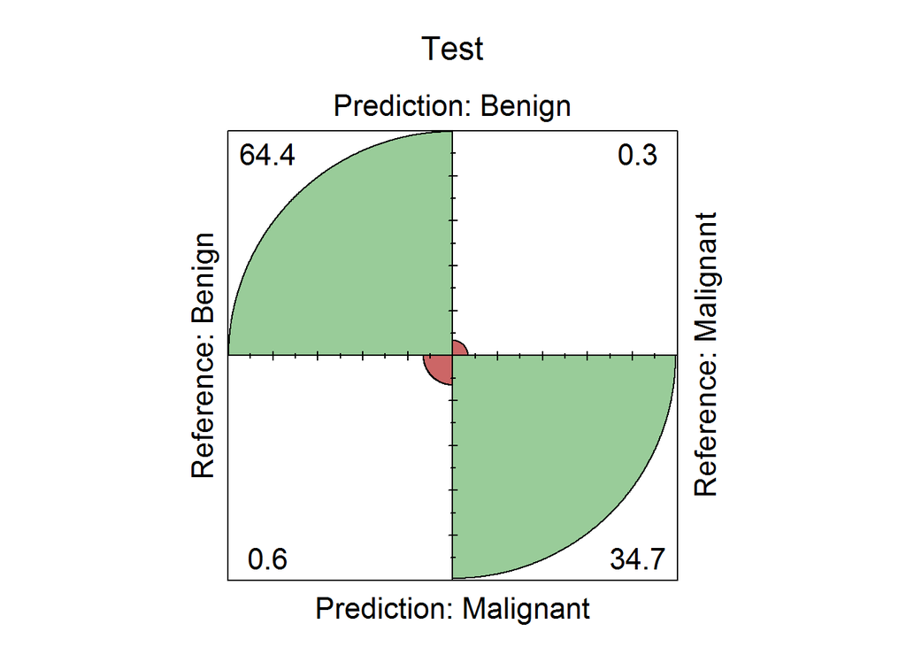

```r
stack.cm <- confusionMatrix(predict(stack.ml,full_wdbc[,1:9]), full_wdbc$wdbc_c)
cm_plot(stack.cm$table/6.83,"Test")
```

```r
stack.metrics <- data.frame (
  "Model" = "Stack",
  "Accuracy" = (stack.cm$table[1,1] + stack.cm$table[2,2])/683,
  "Recall" = stack.cm$table[2,2] / (stack.cm$table[2,2] + stack.cm$table[1,2]),
  "Precision" = stack.cm$table[2,2] / (stack.cm$table[2,1] + stack.cm$table[2,2]),
  "FNR" = (stack.cm$table[1,2] / (stack.cm$table[2,2] + stack.cm$table[1,2])),
  "Fscore" = (2 * stack.cm$table[2,2]) / (2 * stack.cm$table[2,2] + stack.cm$table[1,2] + stack.cm$table[2,1])
)
stack.metrics
```

```
##   Model  Accuracy    Recall Precision         FNR Fscore
## 1 Stack 0.9912152 0.9916318 0.9834025 0.008368201 0.9875
```

## Model Performance

Taking a look at all confusion matrices:

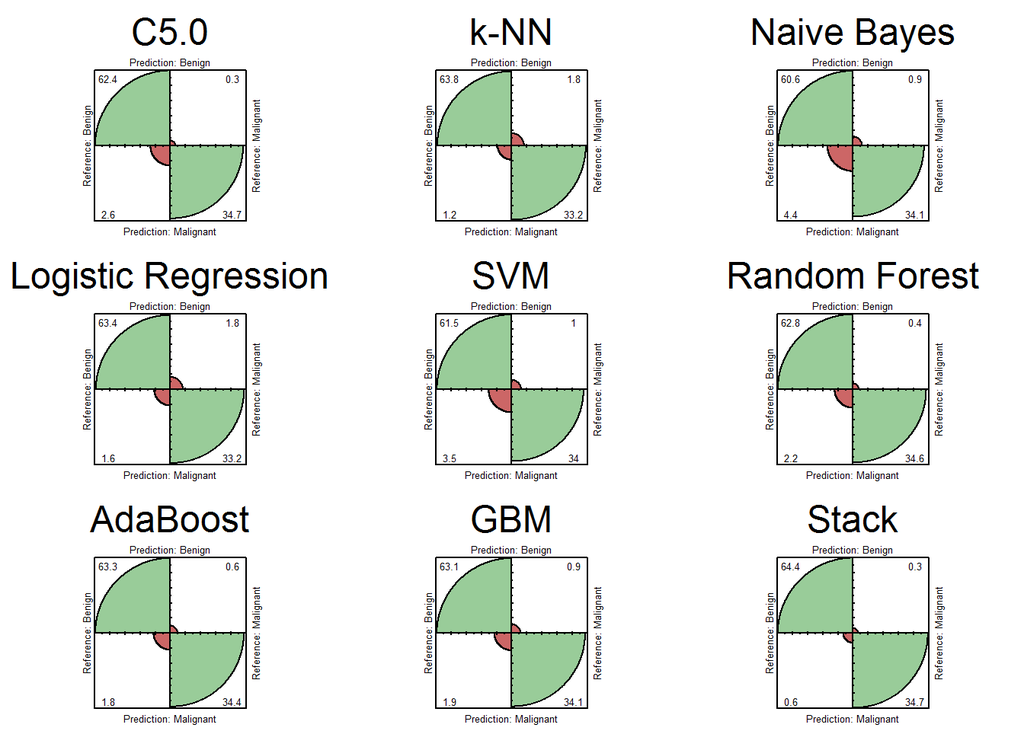

```r
par(mfrow=c(3,3))
cm_plot(c50.ml, "C5.0")
cm_plot(knn.ml, "k-NN")
cm_plot(nb.ml, "Naive Bayes")
cm_plot(logit.ml, "Logistic Regression")
cm_plot(svm.ml, "SVM")
cm_plot(rf.ml, "Random Forest")
cm_plot(ada.ml, "AdaBoost")
cm_plot(gbm.ml, "GBM")
cm_plot(stack.cm$table/6.83,"Stack")
```

Looking at model performance metrics:

```r
metrics2 <- rbind(metrics1, rf.metrics, ada.metrics, gbm.metrics, stack.metrics)
metrics2 # Putting all performance measures together
```

```
##                 Model  Accuracy    Recall Precision         FNR    Fscore
## 1                C5.0 0.9707174 0.9916318 0.9294118 0.008368201 0.9595142
## 2                k-NN 0.9707174 0.9497908 0.9659574 0.050209205 0.9578059
## 3         Naive Bayes 0.9472914 0.9748954 0.8859316 0.025104603 0.9282869
## 4 Logistic Regression 0.9663250 0.9497908 0.9537815 0.050209205 0.9517820
## 5                 SVM 0.9546120 0.9707113 0.9062500 0.029288703 0.9373737
## 6       Random Forest 0.9736457 0.9874477 0.9402390 0.012552301 0.9632653
## 7            AdaBoost 0.9765739 0.9832636 0.9514170 0.016736402 0.9670782
## 8                 GBM 0.9721816 0.9748954 0.9471545 0.025104603 0.9608247
## 9               Stack 0.9912152 0.9916318 0.9834025 0.008368201 0.9875000
```

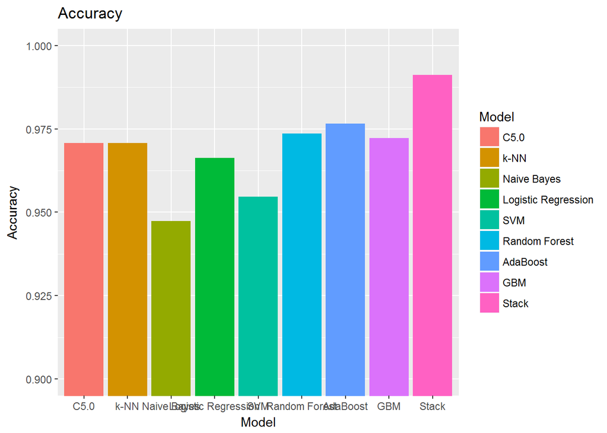

```r
ggplot(metrics2, aes(Model, Accuracy)) + geom_bar(stat="identity", aes(fill=Model)) + coord_cartesian(ylim=c(0.9,1)) + ggtitle("Accuracy")
```

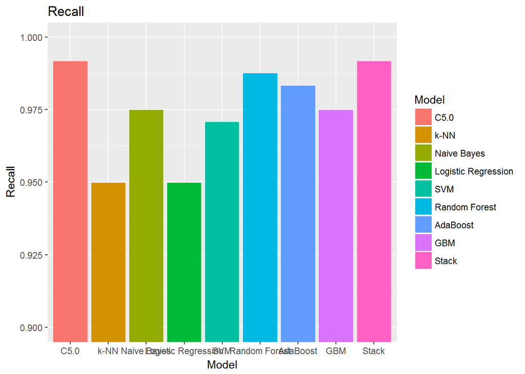

```r
ggplot(metrics2, aes(Model, Recall)) + geom_bar(stat="identity", aes(fill=Model)) + coord_cartesian(ylim=c(0.9,1)) + ggtitle("Recall")
```